# Clase 5: Visualizar e interpretar con ggplot2

Logo de R

Índice general del curso

Vas a escoger un gráfico según la pregunta y explicar qué muestran los datos.

Ejemplo comentado y lecturas adicionales · Referencias

## Agenda

| Minutos | Actividad |
| --- | --- |
| 00–40 | Bloque 1. Comparar categorías con barras |
| 40–75 | Bloque 2. Ver cómo se distribuyen las cantidades |
| 75–85 | Pausa |
| 85–135 | Bloque 3. Explorar la relación entre dos números |
| 135–150 | Repaso de los resultados de las prácticas y consultas |

En cada bloque, primero revisamos la teoría, luego ejecutamos el ejemplo y al final practicamos en parejas o tríos. En cada práctica, alternen quién escribe el código y quién revisa el resultado.

## 1. Comparar categorías con barras

### Teoría

Cuando ya tenés un total por categoría, `geom_col()` usa ese total como longitud de la barra. `aes()` conecta columnas de la tabla con los ejes. La longitud de cada barra representa una cantidad y conviene que empiece en cero para poder comparar las diferencias.

Antes de dibujar las barras, comprobá que la tabla tenga una fila por categoría. Indicá la unidad en el eje de valores y ordená las barras si eso facilita la comparación. Las barras horizontales dejan más espacio para nombres largos.

[Gráficos de barras con ggplot2](https://ggplot2.tidyverse.org/reference/geom_bar.html) · *Learning R* (Cotton, 2013, cap. 14).

### Ejemplo

Fijate en cuál sede tiene el mayor ingreso observado. Con `coord_flip()`, las barras quedan horizontales y el monto en colones se lee de izquierda a derecha. `ggsave()` guarda en un archivo el gráfico que le pasés.

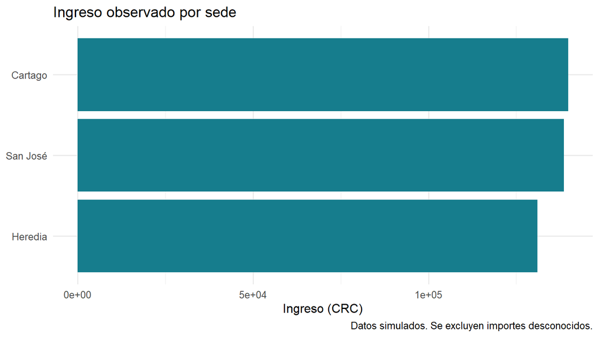

```r
source("herramientas/preparar_datos.R")
library(ggplot2)
ventas <- preparar_ventas()
resumen <- ventas |> group_by(sede) |>
  summarise(ingreso = sum(ingreso_crc, na.rm = TRUE), .groups = "drop")
g <- ggplot(resumen, aes(x = reorder(sede, ingreso), y = ingreso)) +
  geom_col(fill = "#167d8d") + coord_flip() +
  labs(title = "Ingreso observado por sede", x = NULL, y = "Ingreso (CRC)",
       caption = "Datos simulados. Se excluyen importes desconocidos.") +
  theme_minimal(base_size = 12)
print(g)
```

```r
ggsave("salidas/ingreso_sedes.png", g, width = 8, height = 4, dpi = 160)
```

### Práctica en grupo

1. Cambien el agrupamiento del ejemplo para comparar productos por ingreso observado.
2. Construyan barras con `geom_col()`, ordenen los productos por monto y rotulen el eje en colones.
3. Localicen en la tabla el producto con mayor ingreso. Escriban su monto y verifiquen que coincide con la barra correspondiente.
4. Combinen una nota sobre los datos simulados con un título que indique qué ingreso se está comparando.

## 2. Ver cómo se distribuyen las cantidades

### Teoría

Un histograma agrupa una variable numérica en intervalos. Cada barra representa cuántos datos caen dentro de ese intervalo. `binwidth` indica su ancho. Un intervalo más ancho junta más valores. Uno muy angosto puede fragmentar la distribución en muchas barras con pocos casos.

[Histogramas con ggplot2](https://ggplot2.tidyverse.org/reference/geom_histogram.html) · *Learning R* (Cotton, 2013, cap. 14).

### Ejemplo

Usá las ventas con unidades conocidas y fijate cómo cambia el histograma al variar el ancho del intervalo.

```r
ventas_con_unidades <- ventas |> filter(!is.na(unidades))
nrow(ventas_con_unidades)
```

```
## [1] 113
```

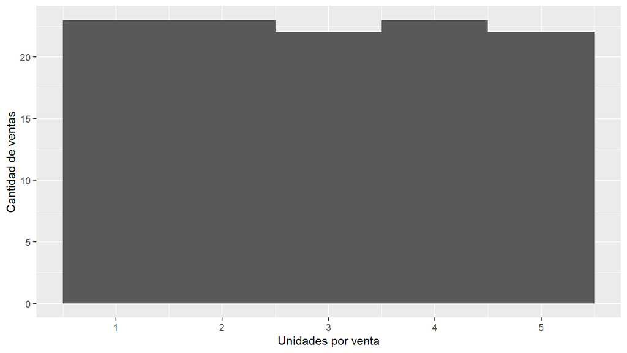

```r
histograma <- ggplot(ventas_con_unidades, aes(unidades)) +
  geom_histogram(binwidth = 1, boundary = 0.5) +
  labs(x = "Unidades por venta", y = "Cantidad de ventas")
print(histograma)
```

### Práctica en grupo

1. Cuenten las ventas con unidades conocidas y las excluidas por falta de unidades.
2. Generen el histograma con `binwidth = 1` y describan qué cantidades se ven con más frecuencia.
3. Repitan con `binwidth = 2` e indiquen qué cantidades quedan agrupadas.
4. Elijan un ancho para comunicar cuántas ventas hubo por cantidad individual y justifiquen la elección.

## 3. Explorar la relación entre dos números

### Teoría

Un gráfico de dispersión representa dos variables numéricas. Cada punto representa una observación. En este ejemplo, ubicás cada venta según su precio y la cantidad de unidades vendidas.

Si dos ventas tienen los mismos valores, los puntos se superponen. Un `alpha` menor hace que se distingan mejor las zonas con muchos puntos. Describí el patrón que ves y sus excepciones. Para explicar por qué ocurre ese patrón haría falta información adicional.

[Gráficos de dispersión con ggplot2](https://ggplot2.tidyverse.org/reference/geom_point.html) · *Learning R* (Cotton, 2013, cap. 14).

### Ejemplo

Fijate dónde se concentran los puntos y en cuáles precios se repiten las cantidades.

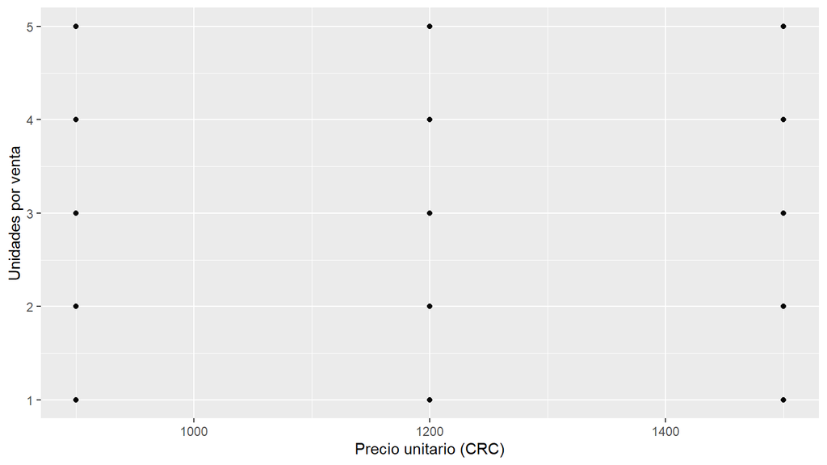

```r
ggplot(ventas_con_unidades, aes(precio_crc, unidades)) +
  geom_point(alpha = 0.4) +
  labs(x = "Precio unitario (CRC)", y = "Unidades por venta")
```

### Práctica en grupo

1. Dibujen la dispersión de precio y unidades. Expliquen qué significa un punto y en qué unidades se lee cada eje.
2. Comparen `alpha = 0.4` con `alpha = 1` e identifiquen una zona donde se superponen datos.
3. Agreguen un título y una nota sobre las ventas con unidades faltantes.
4. Escriban una observación basada en el gráfico y una pregunta que los dos ejes no permitan responder.

## Evaluación fuera de clase

Trabajo grupal II. Resuelvan los diez problemas en equipo fuera de clase.